DS 6030 | Fall 2024 | University of Virginia

# Homework #9: Feature Importance

Author

Published

November 15, 2024

# Required R packages and Directories

```r
dir_data = 'https://mdporter.github.io/teaching/data/' # data directory
library(tidyverse) # functions for data manipulation
```

# Problem 1: Permutation Feature Importance

Vanderbilt Biostats has collected data on Titanic survivors (https://hbiostat.org/data/). I have done some simple processing and split into a training and test sets.

- titanic_train.csv
- titanic_test.csv

We are going to use this data to investigate feature importance. Use `Class`, `Sex`, `Age`, `Fare`, `sibsp` (number of siblings or spouse on board), `parch` (number of parents or children on board), and `Joined` (city where passenger boarded) for the predictor variables (features) and `Survived` as the outcome variable.

## a. Load the titanic traning and testing data

**Solution**

```r
titanic_train <- read.csv(file.path(dir_data, "titanic_train.csv"))
titanic_test <- read.csv(file.path(dir_data, "titanic_test.csv"))

head(titanic_train)
```

```
  Name_ID                                Name    Sex Age Class Ticket
1      36         ALLISON, Miss Helen Loraine female   2     1 113781
2      37 ALLISON, Mr Hudson Joshua Creighton   male  30     1 113781
3      38           ALLISON, Mrs Bessie Waldo female  25     1 113781
4      71              ARTAGAVEYTIA, Mr Ramon   male  71     1  17609
5      87           ASTOR, Colonel John Jacob   male  47     1  17757
6     146                 BAUMANN, Mr John D.   male  60     1  17318
       Joined                       Occupation  Job  Fare sibsp parch Survived
1 Southampton                             <NA> <NA> 151.8     1     2        0
2 Southampton                      Businessman <NA> 151.8     1     2        0
3 Southampton                             <NA> <NA> 151.8     1     2        0
4   Cherbourg                      Businessman <NA>  49.5     0     0        0
5   Cherbourg Property Developer / Real Estate <NA> 247.5     1     0        0
6   Cherbourg                      Businessman <NA>  25.9     0     0        0
```

## b. Method 1: Built-in importance scores

Fit a tree ensemble model (e.g., Random Forest, boosted tree) on the training data. You are free to use any method to select the tuning parameters.

Report the built-in feature importance scores and produce a barplot with feature on the x-axis and importance on the y-axis.

**Solution**

```r
library(tidyverse)
library(randomForest)
set.seed(123)
# implement rf model
titanic_train_clean <- na.omit(titanic_train)
titanic_test_clean <- na.omit(titanic_test)

rf_model <- randomForest(Survived ~ Class + Sex + Age + Fare + sibsp + parch + Joined,
                         data = titanic_train_clean,
                         importance = TRUE)
feature_importance <- importance(rf_model)

# make feature_importance into dataframes for plotting
importance_df <- data.frame(
  Feature = rownames(feature_importance),
  Importance = feature_importance[, "IncNodePurity"]
)

# report built in feature importance
print(feature_importance)
```

```
       %IncMSE IncNodePurity
Class     5.31         0.265
Sex      23.77         4.028
Age       2.68         0.726
Fare     11.88         1.627
sibsp     0.00         0.000
parch     0.00         0.000
Joined    7.15         0.619
```

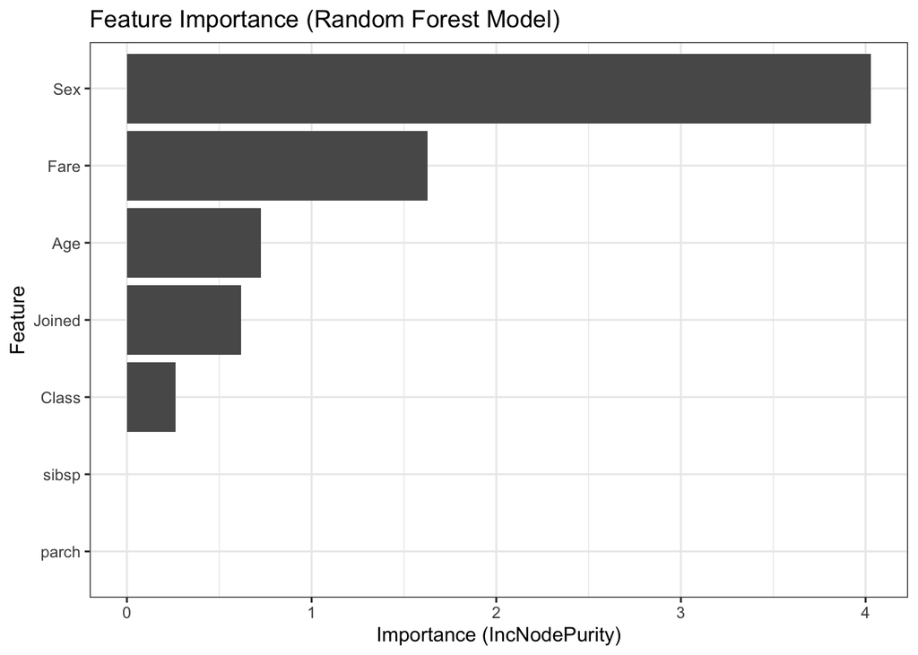

```r
# plotting
ggplot(importance_df, aes(x = reorder(Feature, Importance), y = Importance)) +
  geom_bar(stat = "identity") +
  coord_flip() +
  labs(title = "Feature Importance (Random Forest Model)",
       x = "Feature",
       y = "Importance (IncNodePurity)")
```

## c. Performance

Report the performance of the model fit from (a.) on the test data. Use the log-loss (where $M$ is the size of the test data):
$$\text{log-loss}(\hat{p}) = - \frac{1}{M} \sum_{i=1}^m [y_i \log \, \hat{p}_i + (1 - y_i) \log \, (1 - \hat{p}_i)]$$

**Solution**

```r
# convert survived to factor since it didn't like it
titanic_train_clean$Survived <- as.factor(titanic_train_clean$Survived)
titanic_test_clean$Survived <- as.factor(titanic_test_clean$Survived)

# refit the rf model
rf_model <- randomForest(Survived ~ Class + Sex + Age + Fare + sibsp + parch + Joined,
                         data = titanic_train_clean,
                         importance = TRUE)

# probability prediction for test data
predicted_probs <- predict(rf_model, titanic_test_clean, type = "prob")[, 2]

# extract survival score
actual <- as.numeric(as.character(titanic_test_clean$Survived))

# define log-loss function
log_loss <- function(actual, predicted) {
  -mean(actual * log(predicted) + (1 - actual) * log(1 - predicted))
}

# calculate log-loss
test_log_loss <- log_loss(actual, predicted_probs)
print(paste("Log-loss on test data:", test_log_loss))
```

```
[1] "Log-loss on test data: 0.230461006223859"
```

## d. Method 2: Permute *after* fitting

Use the fitted model from question (a.) to perform permutation feature importance. Shuffle/permute each variable individually on the *test set* before making predictions. Record the loss. Repeat $M=10$ times and produce a boxplot of the change in loss (change from reported loss from part b.).

**Solution**

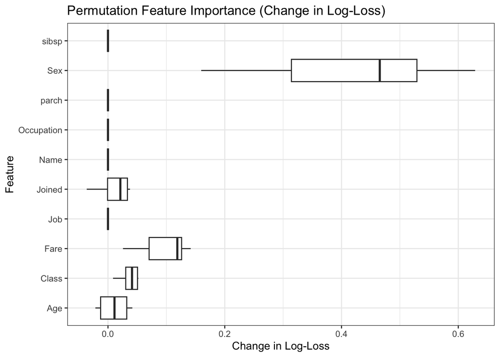

```r
M <- 10

# loss on original data
baseline_loss <- log_loss(actual, predicted_probs)

loss_changes <- data.frame(Feature = character(), LossChange = numeric())
set.seed(123)

# loop over features
for (feature in colnames(titanic_test_clean)[!colnames(titanic_test_clean) %in% c("Survived", "Ticket", "Name_ID")]) {
  # permutation
  for (i in 1:M) {
    test_permuted <- titanic_test_clean
    test_permuted[[feature]] <- sample(test_permuted[[feature]])

    # probability prediction on new permuted data
    permuted_probs <- predict(rf_model, test_permuted, type = "prob")[, 2]

    # calculate log-loss metrics
    permuted_loss <- log_loss(actual, permuted_probs)
    loss_change <- permuted_loss - baseline_loss
    loss_changes <- rbind(loss_changes, data.frame(Feature = feature, LossChange = loss_change))
  }
}

# plot
library(ggplot2)
ggplot(loss_changes, aes(x = Feature, y = LossChange)) +
  geom_boxplot() +
  coord_flip() +
  labs(title = "Permutation Feature Importance (Change in Log-Loss)",
       x = "Feature",
       y = "Change in Log-Loss")
```

## e. Method 3: Permute *before* fitting

For this approach, shuffle/permute the *training data* and re-fit the ensemble model. Evaluate the predictions on the (unaltered) test data. Repeat $M=10$ times (for each predictor variable) and produce a boxplot of the change in loss.

**Solution**

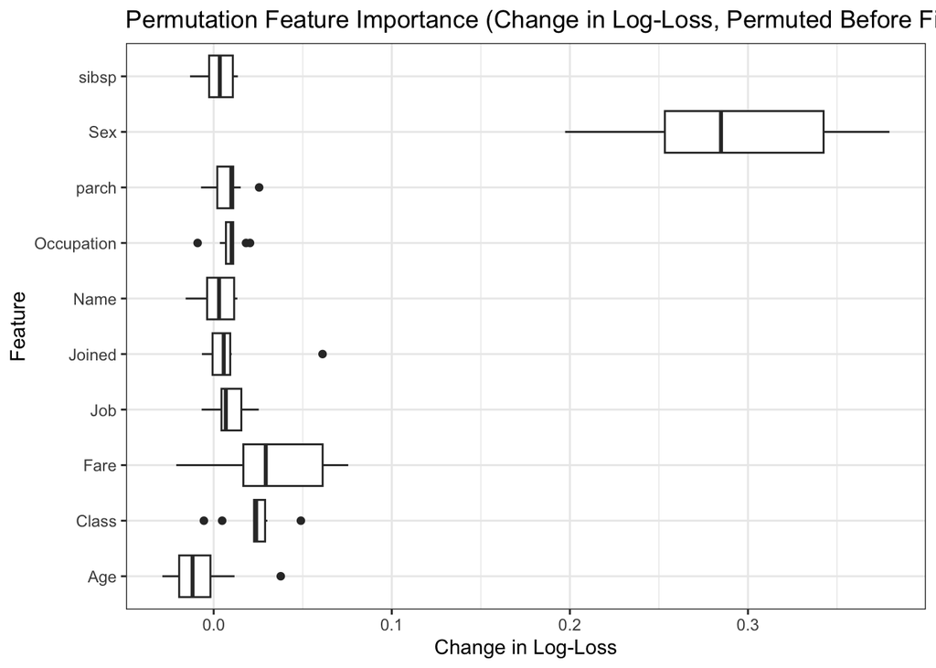

```r
loss_changes <- data.frame(Feature = character(), LossChange = numeric())

# loop over features
for (feature in colnames(titanic_train_clean)[!colnames(titanic_train_clean) %in% c("Survived", "Ticket", "Name_ID")]) {

  # repeat permutation
  for (i in 1:M) {
    train_permuted <- titanic_train_clean
    train_permuted[[feature]] <- sample(train_permuted[[feature]])

    # fir the model after permutation
    rf_model_permuted <- randomForest(Survived ~ Class + Sex + Age + Fare + sibsp + parch + Joined,
                                      data = train_permuted,
                                      importance = TRUE)

    # prediction
    permuted_probs <- predict(rf_model_permuted, titanic_test_clean, type = "prob")[, 2]

    # calculate log-loss metrics
    permuted_loss <- log_loss(actual, permuted_probs)
    loss_change <- permuted_loss - baseline_loss
    loss_changes <- rbind(loss_changes, data.frame(Feature = feature, LossChange = loss_change))
  }
}

# Plot the results
ggplot(loss_changes, aes(x = Feature, y = LossChange)) +
  geom_boxplot() +
  coord_flip() +
  labs(title = "Permutation Feature Importance (Change in Log-Loss, Permuted Before Fitting)",
       x = "Feature",
       y = "Change in Log-Loss")
```

## f. Understanding

Describe the benefits of each of the three approaches to measure feature importance.

**Solution**

built-in importance stores: - it’s very easy to interpret and does not require additional implementation since it’s built into the model itself

permute after fitting: - methodology is the same for different models - by permuting after fitting, we can test how sensitive the model’s performance is to each feature which tells us a lot on feature importance

permute before fitting: - differing from permuting after fitting, if we do permutation before fitting we can see how much each feature contributes to the model’s learning capability

# Problem 2: Effects of correlated predictors

This problem will illustrate what happens to the importance scores when there are highly associated predictors.

## a. Create an almost duplicate feature

Create a new feature `Sex2` that is 95% the same as `Sex`. Do this by selecting 5% of training ($n=50$) and testing ($n=15$) data and flip the `Sex` value.

**Solution**

```r
set.seed(123)

# Create 'Sex2' as a copy of 'Sex' in the training and testing data
titanic_train_clean$Sex2 <- titanic_train_clean$Sex
titanic_test_clean$Sex2 <- titanic_test_clean$Sex

# sample the 5% of training and testing data
train_indices <- sample(1:nrow(titanic_train_clean), size = 50, replace = T)
test_indices <- sample(1:nrow(titanic_test_clean), size = 15, replace = T)

# flip the sex2
titanic_train_clean$Sex2[train_indices] <- ifelse(titanic_train_clean$Sex[train_indices] == "male", "female", "male")
titanic_test_clean$Sex2[test_indices] <- ifelse(titanic_test_clean$Sex[test_indices] == "male", "female", "male")
```

## b. Method 1: Built-in importance

Fit the same model as in Problem 1b, but use the new data that includes `Sex2` (i.e., use both `Sex` and `Sex2` in the model). Calculate the built-in feature importance score and produce a barplot.

**Solution**

```r
set.seed(123)

# fit rf model with new sex2 var
rf_model_with_sex2 <- randomForest(Survived ~ Class + Sex + Sex2 + Age + Fare + sibsp + parch + Joined,
                                   data = titanic_train_clean,
                                   importance = TRUE)

feature_importance <- importance(rf_model_with_sex2)

# make feature_importance into dataframes for plotting
importance_df <- data.frame(
  Feature = rownames(feature_importance),
  Importance = feature_importance[, "MeanDecreaseGini"]
)

# report built in feature importance
print(feature_importance)
```

```
            0       1 MeanDecreaseAccuracy MeanDecreaseGini
Class   0.738  6.1812                4.989            0.593
Sex    21.186 24.2431               25.404            7.933
Sex2    0.989  4.2519                3.344            1.106
Age     0.183 -0.0979               -0.161            1.419
Fare    6.007  9.6289                9.773            3.497
sibsp   0.000  0.0000                0.000            0.000
parch   0.000  0.0000                0.000            0.000
Joined  4.373  4.8708                5.984            1.139
```

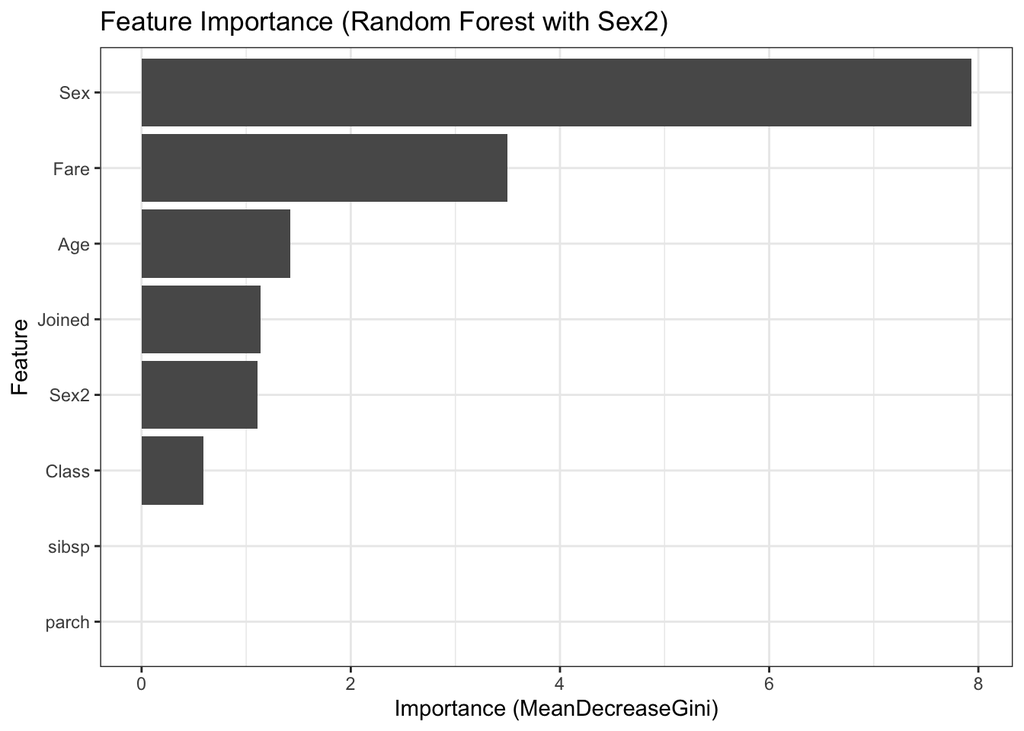

```r
# plot
ggplot(importance_df, aes(x = reorder(Feature, Importance), y = Importance)) +
  geom_bar(stat = "identity") +
  coord_flip() +
  labs(title = "Feature Importance (Random Forest with Sex2)",
       x = "Feature",
       y = "Importance (MeanDecreaseGini)")
```

## c. Method 2: Permute *after* fitting

Redo Method 2 (problem 1d) on the new data/model and produce a boxplot of importance scores. The importance score is defined as the difference in loss.

**Solution**

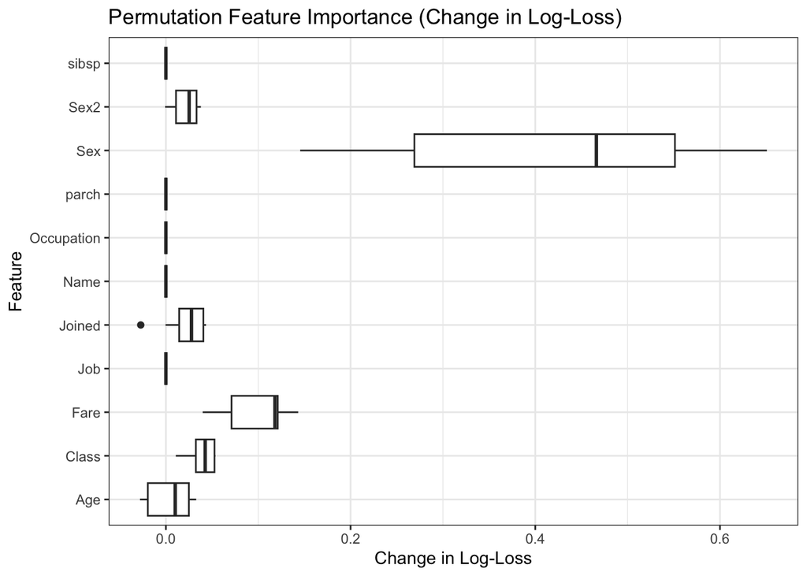

```r
M <- 10

# calculate baseline metrics
predicted_probs <- predict(rf_model_with_sex2, titanic_test_clean, type = "prob")[, 2]
actual <- as.numeric(as.character(titanic_test_clean$Survived))
baseline_loss <- log_loss(actual, predicted_probs)

loss_changes <- data.frame(Feature = character(), LossChange = numeric())
set.seed(123)


for (feature in colnames(titanic_test_clean)[!colnames(titanic_test_clean) %in% c("Survived", "Ticket", "Name_ID")]) {

  for (i in 1:M) {
    test_permuted <- titanic_test_clean
    test_permuted[[feature]] <- sample(test_permuted[[feature]])
    permuted_probs <- predict(rf_model_with_sex2, test_permuted, type = "prob")[, 2]
    permuted_loss <- log_loss(actual, permuted_probs)
    loss_change <- permuted_loss - baseline_loss
    loss_changes <- rbind(loss_changes, data.frame(Feature = feature, LossChange = loss_change))
  }
}

ggplot(loss_changes, aes(x = Feature, y = LossChange)) +
  geom_boxplot() +
  coord_flip() +
  labs(title = "Permutation Feature Importance (Change in Log-Loss)",
       x = "Feature",
       y = "Change in Log-Loss")
```

## d. Method 3: Permute *before* fitting

Redo Method 3 (problem 1e) on the new data and produce a boxplot of importance scores. The importance score is defined as the difference in loss.

**Solution**

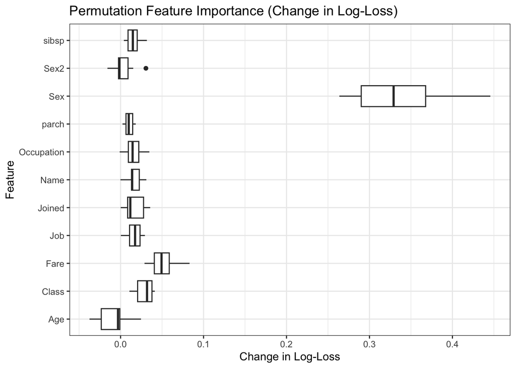

```r
M <- 10

predicted_probs <- predict(rf_model_with_sex2, titanic_test_clean, type = "prob")[, 2]
baseline_loss <- log_loss(actual, predicted_probs)

loss_changes <- data.frame(Feature = character(), LossChange = numeric())
set.seed(123)

for (feature in colnames(titanic_train_clean)[!colnames(titanic_train_clean) %in% c("Survived", "Ticket", "Name_ID")]) {

  for (i in 1:M) {
    train_permuted <- titanic_train_clean
    train_permuted[[feature]] <- sample(train_permuted[[feature]])
    rf_model_permuted <- randomForest(Survived ~ Class + Sex + Sex2 + Age + Fare + sibsp + parch + Joined,
                                      data = train_permuted,
                                      importance = TRUE)
    permuted_probs <- predict(rf_model_permuted, titanic_test_clean, type = "prob")[, 2]
    permuted_loss <- log_loss(actual, permuted_probs)
    loss_change <- permuted_loss - baseline_loss
    loss_changes <- rbind(loss_changes, data.frame(Feature = feature, LossChange = loss_change))
  }
}


ggplot(loss_changes, aes(x = Feature, y = LossChange)) +
  geom_boxplot() +
  coord_flip() +
  labs(title = "Permutation Feature Importance (Change in Log-Loss)",
       x = "Feature",
       y = "Change in Log-Loss")
```

## e. Understanding

Describe how the addition of the almost duplicated predictor impacted the feature importance results.